# Séance 5.1: Paramètres de variation

08 February 2023

## Plan de présentation

- Mesures
- Extension
  - Scores standardisés ou scores-Z
  - Loi normale
  - Distribution d’échantillonnage
  - Théorème central limite
  - Intervalles de confiances

## Introduction

- Bien que la moyenne soit la caractéristique la plus importante résumant une distribution à l’aide d’un seul nombre, il est nécessaire aussi d’étudier comment les observations sont dispersées, ou variées.
- On donne l’exemple d’homme qui s’est noyé dans un ruisseau qui avait en moyenne 10 centimètres de profondeur
- De même qu’il existe différentes mesures de valeur centrale, on trouve de nombreuses mesures de la dispersion.
- deux d’entre elles sont généralement utilisées:
- l’**intervalle interquartile** et
- l’**écart type**
- Nous en citerons d’autres tout au long de la présentation

## Étendue

- L’**étendue** (ou *range* ou *amplitude*) est simplement la différence entre la plus grande et la plus petite valeur de la variable.
- Étendue = plus grande observation - plus petite observation

## Étendue Interquartile (EIQ)

- Au lieu d’utiliser les deux observations extrêmes, prenons les deux quartiles.
- les deux quartiles sont beaucoup plus stables (i.e. stables à l’influence indue d’une seule observation).
- La distance séparant les quartiles mesure la dispersion de la moitié centrale des observations: c’est pourquoi on l’appelle **étendue interquartile (EID)**, ou **dispersion centrale**.
- EIQ = 3ème quartile - 1er quartile
- Limite: Elle n’utilise pas l’ensemble des observations de la distribution.

## Variance

- La **variance** est la moyenne arithmétique des carrés des écarts à la moyenne
- Elle mesure la dispersion, l’étalement, et la variabilité des valeurs
- Pour une distribution, la variance est:

\[Variance = s^2 = \frac{1}{n-1} \sum_{i=1}^n (X_i - \bar{X})^2\]

\[s^2 = \frac{1}{n-1} *[(X_1 - \bar{X})^2 + (X_2 - \bar{X})^2 + ... + (X_n - \bar{X})^2]\]

- \(X_1, X_2, ... , X_n\) sont les n valeurs observées et \(\bar{X}\) = moyenne de la distribution

## Variance

- Pour les données classées, il faut modifier cette formule, en pondérant chaque écart par sa fréquence.

\[Variance, s^2 = \frac{1}{n-1} \sum_{i=1}^p f_i(x_i - \bar{x})^2\]

- \(x_1, x_2, ... , x_p\) étant les p occurrences observées avec \(n_1, n_2, ... , n_p\), les effectifs correspondants de ces occurrences.
- \(f_1, f_2, ... , f_p\) sont les fréquences relatives et \(\bar{x}\) = moyenne de la distribution groupée (classée)

## Autres exemples

| Groupe A: | Groupe B | Groupe C |
| --- | --- | --- |
| Relativement homogène | Entre les deux | Relativement hétérogènes |

64 44 34 68 63 58 70 80 90 71 91 101 69 74 79 66 56 46 **68** **68** **68**

- En gras, moyenne de chaque groupe

## Écart type

- Pour éliminer le fait d’avoir utilisé le carré des écarts, on calcule finalement la racine carrée de la variance: ceci donne la façon la plus générale de mesurer l’écart par rapport à la moyenne, appelée pour cette raison son écart type **s**
- **écart-type** = racine carrée de la **variance**

## En résumé : Mesure de tendance centrale (paramètres de position)

| Symbole | Définition | Formules |
| --- | --- | --- |
| Moyenne | Somme des valeurs divisée par | \(\bar{X} = \frac{1}{n} \sum_{i=1}^n X_i\) |
|  | l’effectif de la série |  |
| Médiane | Valeur qui divise la distribution |  |
|  | en deux parties égales |  |
| Mode | Valeur observée de fréquence maximum |  |
| Percentile | Valeurs qui divisent la distribution |  |
|  | en 100 parties égales |  |

## En résumé : Mesure de dispersion

| Symbole | Définition | Formules |
| --- | --- | --- |
| Étendue | Différence entre la plus grande | G - P |
|  | et la plus petite valeur de la |  |
|  | variable |  |
| EIQ | 3ème quartile - 1er quartile | Q3 - Q1 |
| Déviation | La distance d’une valeur à | \(X - \bar{X}\) |
|  | la moyenne |  |
| Sommes | Somme des carrés des déviations | SC = \(\sum_{i=1}^n (X_i - \bar{X})^2\) |
| des carrés |  |  |
| Variance | Moyenne des carrés des déviances | \(s^2 = \frac{1}{n-1} \sum_{i=1}^n (X_i - \bar{X})^2\) |
| Écart-type | Racine carrée de la variance | \(s = \sqrt{\frac{1}{n-1} \sum_{i=1}^n (X_i - \bar{X})^2}\) |

## Scores standardisés ou scores-Z

- Un score standardisé mesure à combien d’écarts-types de la moyenne se situe un score donné
- Sa formule est :

\[Z_i = \frac{X_i - \bar{X}}{s}\]

- \(Z_i\) = le score standadisé du \(i^e\) cas
- \(X_i\) = le score du \(i^e\) cas
- \(\bar{X}\) = la moyenne
- s = l’écart-type
- Ils sont particulièrement utiles lorsque l’on compare des scores provenant de distribution dont les moyennes et les écarts-types sont différentes.

## Scores standardisés ou scores-Z

- Exemple: Qui de Bill avec un revenu de 80000 au Québec et Alice avec un revenu de 110000 à Alberta a le meilleu revenu dans sa province?
- Rappelons que
  - le revenu moyen à Alberta 103446.28 est et l’ecart-type vaut 92722.25
  - le revenu moyen au Québec 71150.87 est et l’écart-type vaut 46601.69

## Scores standardisés ou scores-Z

- Calculons les scores standardisés de Bill et de Alice

```r
# Québec
Score_z_bill <- (80000 - 71150.87)/46601.69
Score_z_bill
```

```
## [1] 0.1898886
```

```r
# Alberta
Score_z_alice <- (110000 - 103446.28)/92722.25
Score_z_alice
```

```
## [1] 0.0706812
```

- On voit que Bill a un revenu qui se situe à 0.19 écart type de la moyenne des revenus au Québec alors qu’Alice ne se trouve qu’à 0.07 écart-type. Donc, le revenu de Bill est meilleur que le revenu d’Alice.

## Exercice

Voici les scores de 6 individus:

| Individu | Score (Xi) |
| --- | --- |
| 1 | 64 |
| 2 | 68 |
| 3 | 70 |
| 4 | 71 |
| 5 | 69 |
| 6 | 66 |

1. Calculer les scores sstandardisés (Zi) de chaque individu
2. Calculer la moyenne des scores (Zi). Quelle conclusions tirez-vous?
3. Calculer l’écart-type des scores (Zi). Quelle conclusion tirez-vous?
4. Pouvez-vous démontrer les résultats obtenus au 2 et 3 à partir de la formule du score standardisé?

## Solution

```r
Score <- c(64, 68, 70, 71, 69, 66)
Score
```

```
## [1] 64 68 70 71 69 66
```

```r
Z_score <- (Score - mean(Score))/sd(Score)
Z_score
```

```
## [1] -1.5339300  0.0000000  0.7669650  1.1504475  0.3834825 -0.7669650
```

```r
# Moyenne
mean(Z_score)
```

```
## [1] 0
```

```r
# Écart-type
sd(Z_score)
```

```
## [1] 1
```

## La distribution normale

- La distribution normale est une distribution particulière, symétrique en forme de cloche
- Ce n’est pas toutes les distributions en forme de cloche qui sont normales
- Une distribution normale doit s’écrire sous la forme:

\[Y = \frac{e^{-(x - \mu)^2/2\sigma^2}}{\sigma\sqrt{2\pi}}\] - \(\mu\) est la moyenne et \(\sigma\) l’écart-type

- Elle est notée \(N(\mu, \sigma)\)

## La distribution normale

Voici deux distributions normales

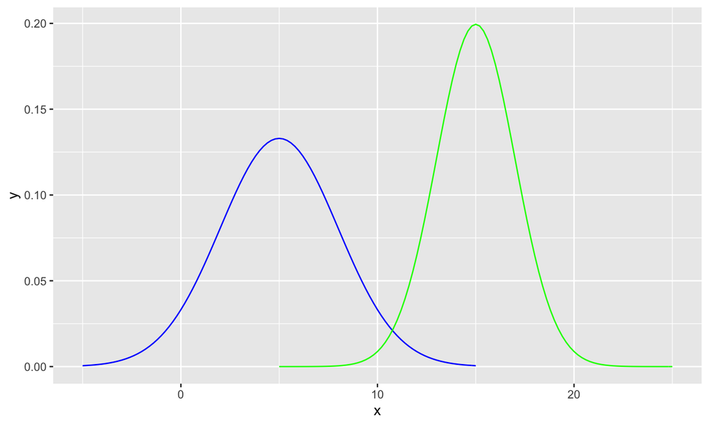

## La distribution normale: Propriété

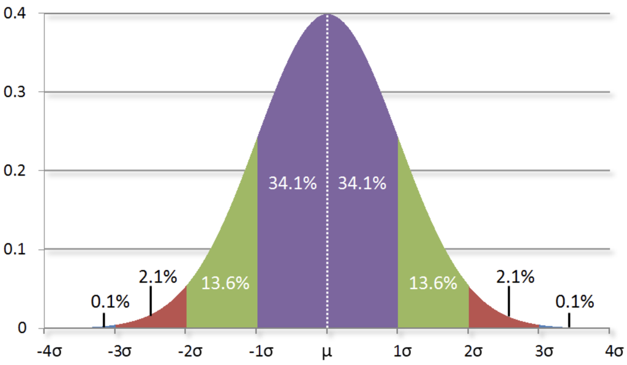

Quelque soit la forme de la loi normale:

1. L’intervalle d’un écart-type de part et d’autre de la moyenne contient 68% de la distribution
2. L’intervalle de deux écart-types de part et d’autre de la moyenne contient 95% de la distribution
3. L’intervalle de trois écart-types de part et d’autre de la moyenne contient 99,7% de la distribution

## Ecart-type correspondant à x pourcentage de la distribution

- Il est préférable de partir de l’intervalle de déterminer plus précisément le nombre d’écart-type qui délimite l’intervalle.
- Par exemple, quel intervalle contient 60% de la distribution?
- Autrement dit, comme la courbe est symétrique, on dira que 30% de la distribution se trouve entre la moyenne et la valeur recherchée. Donc que 20% se trouve au-delà.
- Prob(distribution < v1) = 0.2 nous donne tout simplement la valeur de 20 ième percentile de la distribution
- Prob(distribution < v2) = 0.8 dit que 80% de la distribution est inférieure à cette valeur.
- Donc l’intervalle [V1, V2] contient 60% (80% - 20%) de la distribution

## Ecart-type correspondant à x pourcentage de la distribution

On peut le calculer assez facilement avec la fonction qnorm.

```r
v1 <- qnorm(0.20, mean = 5, sd = 3)
v1
```

```
## [1] 2.475136
```

```r
v2 <- qnorm(0.80, mean = 5, sd = 3)
v2
```

```
## [1] 7.524864
```

- Ainsi, on trouve que l’intervalle en question est [2,47; 7,52] pour la distribution normale N(5, 3).
- Cet intervalle contient 60% de la distribution

## Ecart-type correspondant à x pourcentage de la distribution

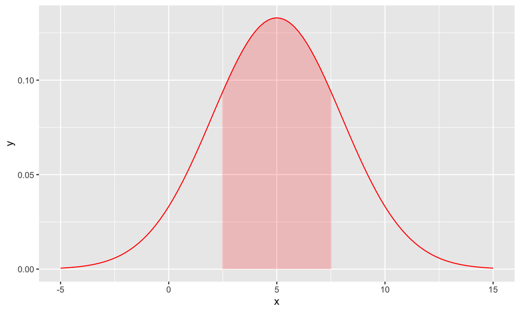

```r
ggplot(data = data.frame(x = c(-5, 15)), aes(x)) +
  stat_function(fun = dnorm, args = list(mean = 5, sd = 3), color = "red") +
  stat_function(fun = dnorm, args = list(mean = 5, sd = 3),
                geom = "area", fill = "red", xlim = c(v1, v2), alpha = 0.2)
```

## Loi normale (centrée réduite)

- Calculer les quantiles pour différentes distributions normales peut être fastidieux (dans le temps).
- Alors, les statisticiens ont calculé cela pour la distribution normale centrée réduite
- Lorsque la moyenne vaut 0 et l’écart-type vaut 1, on parle de distribution normale centrée réduite
- Vous comprenez donc que si vous standardisez les scores de votre distribution normale, vous trouvez une distribution normale centrée réduite

## Loi normale (centrée réduite)

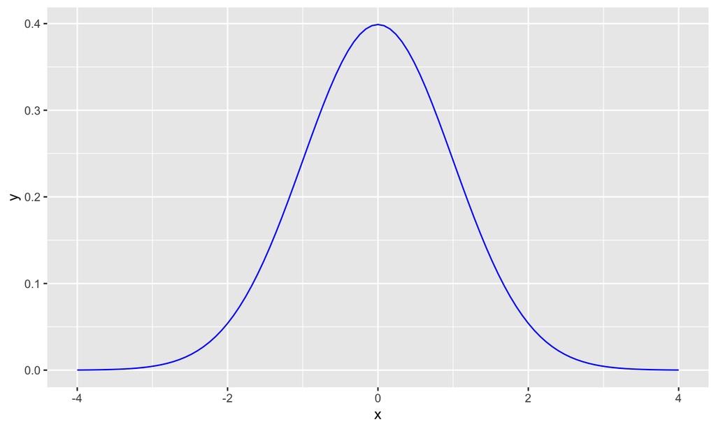

```r
courbe_normale <-
  ggplot(data = data.frame(x = c(-4, 4)), aes(x)) +
  stat_function(fun = dnorm, args = list(mean = 0, sd = 1), color = "blue")

courbe_normale
```

```r
?dnorm
```

## Loi normale (centrée réduite)

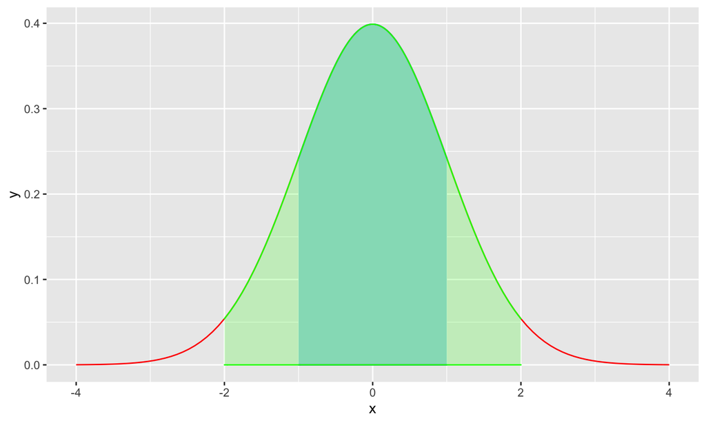

- On voit que 68% de la distribution est comprise entre -1 et 1 écart-type (vert foncé)
- On voit que 95% de la distribution est comprise entre -2 (-1.96) et 2 (1.96) écarts-types (vert clair)

## Lecture du tableau de distribution

Voir livre

## Distribution d’échantillonnage

## Distribution d’échantillonnage

- Il est possible d’utiliser des distributions de données d’échantillon afin de décrire la population de laquelle fut tiré l’échantillon
- Une **distribution d’échantillonnage** (par exemple de la moyenne) est la distribution de l’ensemble des moyennes calculées sur l’ensemble des échantillons possibles de taille N qu’on peut tirer de cet échantillon

## Distribution d’échantillonnage

- Exemple simple
  - Voici les âges de 4 personnes {10, 11, 13, 14}
  - Voici les échantillons possibles de 3 personnes qu’on peut tirer de cette population:
- (10, 11, 13) avec la moyenne de 11,3 ans
- (10, 11, 14) avec la moyenne de 11,7 ans
- (11, 13, 14) avec la moyenne de 12,7 ans
- (10, 13, 14) avec la moyenne de 12,3 ans
- 11.3; 11.7; 12.7 et 12.3 est appellé la distribution d’échantillonnage

## Distribution d’échantillonnage

- Exemple simple
- 11.3; 11.7; 12.7 et 12.3 est appellé la distribution d’échantillonnage
- Quel est la moyenne de cette distribution d’échantillonnage?
- Que constatez-vous?

## Distribution d’échantillonnage

https://www.alloprof.qc.ca/fr/eleves/bv/mathematiques/les-permutations-les-arrangements-et-les-combinai-m1346

## Distribution d’échantillonnage - propriété

- A mesure qu’augmente la taille N de l’échantillon, la distribution d’échantillonnage de la moyenne s’apparente de plus en plus à une distribution normale, dont la moyenne est semblable à celle de la **population** et dont l’écart-type est de \(\frac{\sigma}{\sqrt{N}}\)
- On nomme cela le **théorème de limite centrale**
- L’écart-type de la distribution d’échantillonnage est appelé **erreur-type**
- Il vaut: \(\frac{\sigma}{\sqrt{N}}\)

## Exemple

- Supposons que le salaire moyen issu d’un échantillon de 1000 Québécois vaut 65000$ et l’écart-type de 32000.
- On dira que le salaire moyen des Québécois vaut 65000$. Mais, ce faisant on commet une ereur.
- Si nous approximons aussi l’écart-type du salaire de la population par l’écart-type du salaire de l’échantillon, on peut alors dire que l’erreur-type vaut:
- 32000/racine_carré (1000) = 1012

## Intervalle de confiance

## Intervalle de confiance

- La meilleure estimation que nous pouvons avoir de la moyenne de la population est la moyenne de l’échantillon
- Cependant, cette moyenne calculée à partir d’un seul échantillon peut être soit plus élevée, ou plus faible que la vraie moyenne de la population
- Il parait donc extrêmement utile de déterminer l’intervalle, de part et d’autre de la moyenne, à l’intérieur duquel il est probable de trouver la moyenne de la population
- L’erreur-type va nous aider à trouver cela

## Intervalle de confiance

Le théorème de la limite centrale nous permet de déterminer cette intervalle.

- On sait que plus N est grand, plus la distribution d’échantillonnge va suivre la distribution normale N(moyenne de l’échantillon, \(\sigma/\sqrt(N)\))
- On sait aussi que dans une distribution normale, 95% de la distribution se trouve à plus ou moins 2 écart-types de la moyenne (plus précisément à 1.96 écart-type)
- Ainsi, l’intervalle de confiance à 95% sera déterminée par:

## Intervalle de confiance

\[ [\bar{X} - 1.96\sigma_{\bar{X}} , \bar{X} + 1.96\sigma_{\bar{X}}]\]

- Dans l’exemple précédent, on dira que dans 95% des cas, le salaire moyen de la population Québécoise va se trouver dans l’intervalle [65000 - 1.96x1012, 65000 + 1.96x1012], soit [63016, 66983]
- 1,96 est la valeur du score standardisé correspondant à l’intervalle de 95%

## Théorème central limite - Règle de l’Approximation Normale (généralité)

## Dégré de fiabilité de l’échantillon

- Le but de l’échantillonnage aléatoire est d’éffectuer une inférence relative à la population sous-jacente.
- On souhaite que la moyenne de l’échantillon - \(\bar{X}\) soit une estimation proche de la moyenne de la population - \(\mu\).
- Deux façons d’étudier le degré d’approximation de \(\mu\) par \(\bar{X}\).
1. A partir de formules mathématiques
2. A partir de la distribution d’échantillonnage

## Moments de la moyenne de l’échantillon

- On démontre que :
- E(\(\bar{X}\)) = \(\mu\) : la moyenne de l’échantillonnage \(\bar{X}\) coïncidera en moyenne avec l’objectif, ie. \(\bar{X}\) égalisera \(\mu\)
- Erreur type d’échantillon (standard error) = SE = \(\sigma_{\bar{X}}\) = \(\frac{\sigma}{\sqrt{n}}\), où \(\sigma\) est l’écart type dans la population
- L’erreur type de \(\bar{X}\) diminue quand la taille de l’échantillon aléatoire augmente.
- Plus l’échantillon est grand, plus \(\bar{X}\) donne une estimation exacte de la moyenne de la population.
- **NB**: Ne pas confondre:
- écart type (en anglais, standard deviation) et
- erreur type ou écart type d’échantillon (en anglais, standard error)

## Forme de la distribution d’échantillonnage

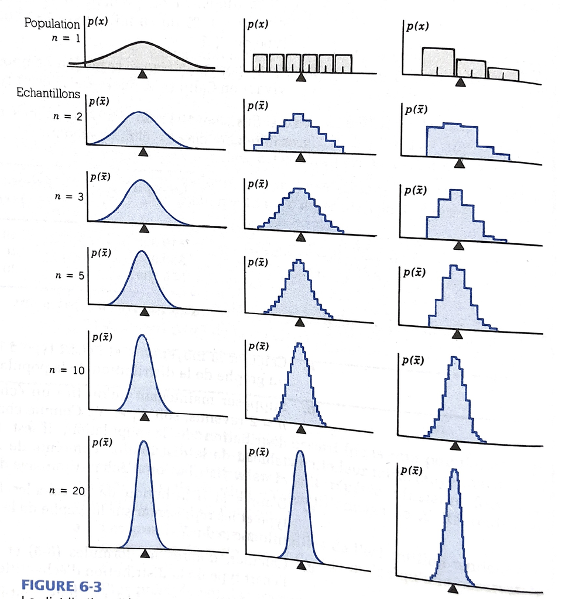

## Théorème central limite (Règle de l’Approximation Normale)

Dans les échantillons aléatoires de taille n, la moyenne de l’échantillon \(\bar{X}\) varie autour de la moyenne de la population \(\mu\) avec un écart type égal à \(\frac{\sigma}{\sqrt{n}}\) (ou \(\sigma\) est l’écart type de la population). Donc, quand n s’accroît, la distribution d’échantillonnage de \(\bar{X}\) est de plus en plus concentrée autour de son objectif \(\mu\). Elle devient de plus en plus proche de la distribution normale (forme de cloche).

## Théorème central limite (Règle de l’Approximation Normale)

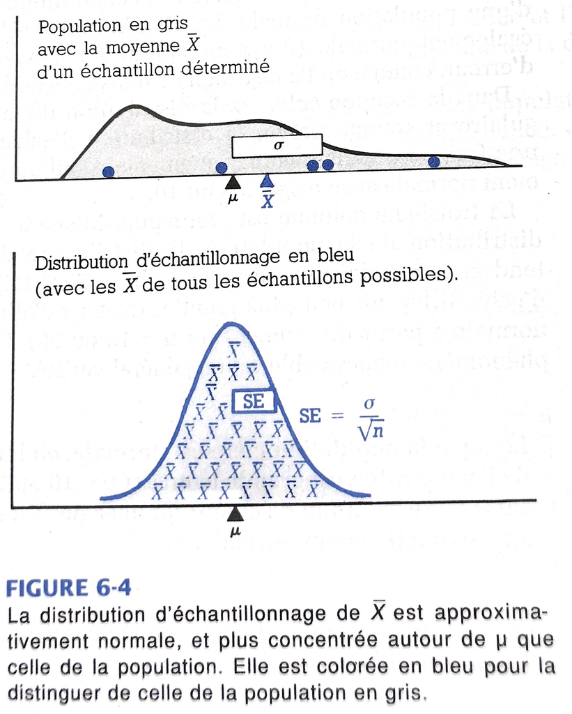

## Théorème de la limite centrale (Règle de l’Approximation Normale)

- Dire que la moyenne de l’échantillon \(\bar{X}\) varie autour de la moyenne de la population \(\mu\) avec une erreur type \(\sigma_{\bar{X}}\) égale à \(\frac{\sigma}{\sqrt{n}}\) revient à dire que la distribution \(\bar{X}\) suit une loi normale de moyenne \(\mu\) et d’écart type \(\frac{\sigma}{\sqrt{n}}\)
- \(\bar{X}\) suit \(N(\mu, \frac{\sigma}{\sqrt{n}})\)
- Ou que (\(\frac{(\bar{X}-\mu)}{\frac{\sigma}{\sqrt{n}}}\)) suit une loi **normale dite centrée réduite** N(0,1)

## Théorème de la limite centrale (Règle de l’Approximation Normale) - Exemple

Une population d’étudiants d’un grand campus du Middle-West a une taille moyenne de \(\mu\) = 175.26 cm (69 inches) et un écart type \(\sigma\) = 8.18cm (3.22 inches). Si un échantillon aléatoire de n = 10 individus est prélevé, quelle est la probabilité pour que la moyenne de l’échantillon \(\bar{X}\) s’écarte de 5.08 cm (2 inches) de la moyenne de la population?

```
## [1] 1.018253
```

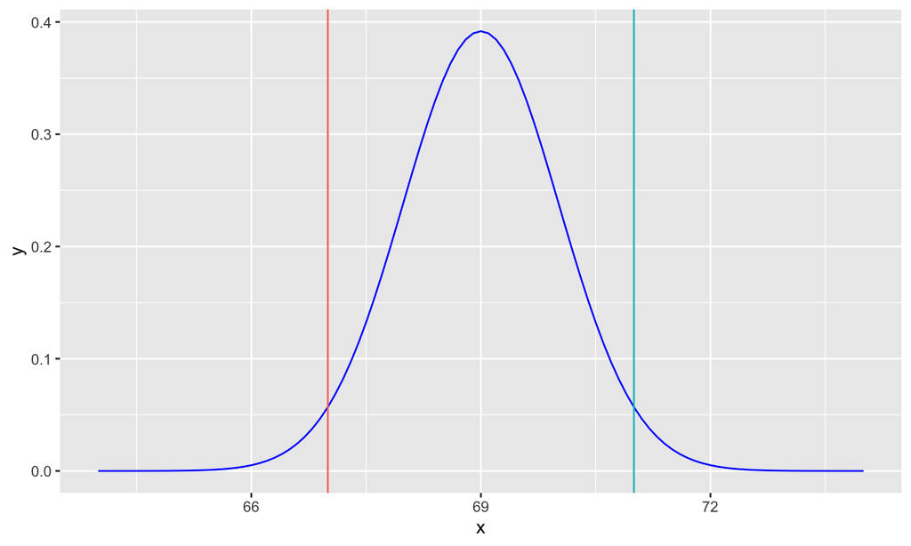

## Théorème central limite (Règle de l’Approximation Normale) - Exemple

- **Réponse**:
- Selon la Règle de l’Approximation Normale, \(\bar{X}\) est normalement distribuée avec:
- Espérance = \(\mu\) = 69 et
- Écart type d’échantillon = \(\sigma_{\bar{X}} = \frac{\sigma}{\sqrt{n}} = \frac{3.22}{\sqrt{10}}\) = 1.02
- On cherche à déterminer la probabilité que \(\bar{X}\) s’écarte de 2 inches de \(\mu\), c’est à dire qu’elle se trouve entre 67 et 71.
- Aussi, calcule-t-on, d’abord la probabilité que \(\bar{X}\) soit supérieur à 71, en commençant par centrer et réduire:

\[\text{Z = } \frac{\bar{X}-\mu}{\sigma_{\bar{X}}} = \frac{71 - 69}{1.02} = 1.96\]

- Cela signifie que la valeur critique de 71 pour que la moyenne de l’échantillon est environ de 2 écarts-type au dessus de son espérance 69.

## Théorème central limite (Règle de l’Approximation Normale) - Exemple

- D’après le tableau de la loi normale centrée réduite, on trouve que la probabilité que Z excède 1.96 est seulement de 0.025. C’est ce que montre la partie droite hachurée sur la figure (montrer la figure en classe).
- En raison de la symétrie de la distribution normale, l’extrémité gauche a la même probabilité 0.025.
- Ainsi, on peut déterminer la probabilité cherchée de la partie centrale : \(Probabilité = 1.000 - 0.025 - 0.025 = 0.95\)
- On conclut donc qu’il y a 95% de chance pour que la moyenne de l’échantillon s’écarte de 2 inches de la moyenne de la population

## Théorème central limite (Règle de l’Approximation Normale) - Question

1. Quelle est la probabilité que cette moyenne s’écarte de 1 inche de la moyenne de la population? Est-ce que cette probabilité va être plus grande ou plus pétite que la première?
2. Quelle est la probabilité que cette moyenne s’écarte de 3 inches de la moyenne de la population? Est-ce que cette probabilité va être plus grande ou plus pétite que la première?